# EDA: LAB-1 Regression Analysis

Name: Aryan Vigyat 20BCE1452

Date: 16th December 2022

1. Creating the DataFrame with the given vectors

```r
library(readr)
library(caret)
x=c(2,3,4,5,6)
y=c(12,17,23,28,32)
df=data.frame(x,y)
print(df)
```

```
##   x  y
## 1 2 12
## 2 3 17
## 3 4 23
## 4 5 28
## 5 6 32
```

2. Find the best linear fit and graph of the model

```r
model1<-lm(y~x,data=df)
model1
```

```
##
## Call:
## lm(formula = y ~ x, data = df)
##
## Coefficients:
## (Intercept)            x
##         2.0          5.1
```

```r
summary(model1)
```

```
##
## Call:
## lm(formula = y ~ x, data = df)
##
## Residuals:
##    1    2    3    4    5
## -0.2 -0.3  0.6  0.5 -0.6
##
## Coefficients:
##             Estimate Std. Error t value Pr(>|t|)
## (Intercept)   2.0000     0.8124   2.462 0.090720 .
## x             5.1000     0.1915  26.634 0.000116 ***
## ---
## Signif. codes:  0 '***' 0.001 '**' 0.01 '*' 0.05 '.' 0.1 ' ' 1
##
## Residual standard error: 0.6055 on 3 degrees of freedom
## Multiple R-squared:  0.9958, Adjusted R-squared:  0.9944
## F-statistic: 709.4 on 1 and 3 DF,  p-value: 0.0001161
```

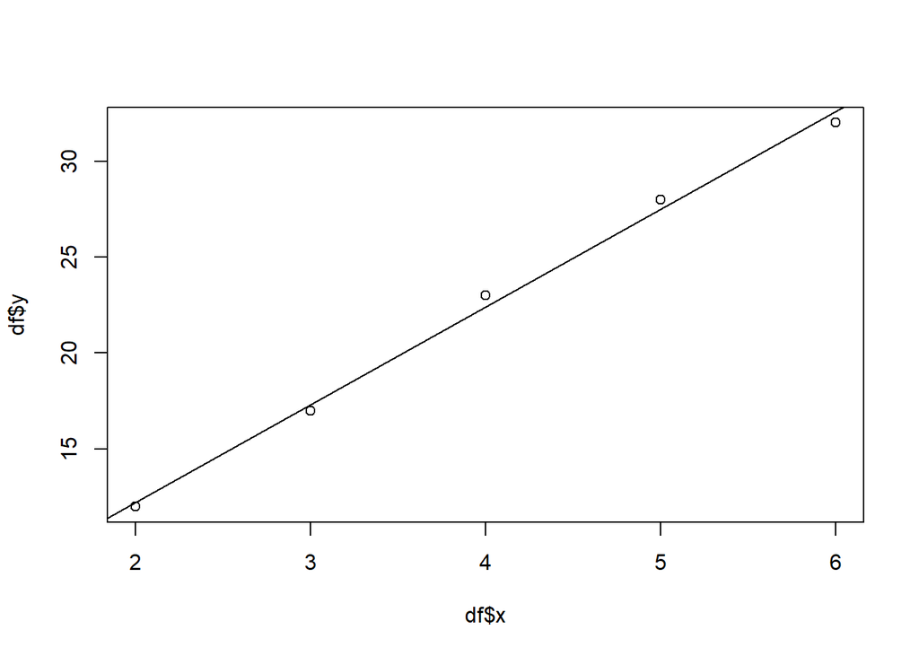

```r
plot(df$x,df$y)
abline(model1,col="black")
```

3. Determine the minimum RSS

```r
ypre=predict(model1,df)
ydiff=y-ypre
rss<-0
for(i in ydiff)
{
  rss=rss+i*i
}
rss
```

```
## [1] 1.1
```

4.Draw the Residual Plot and Comment on the suitability of the linear model to this training data

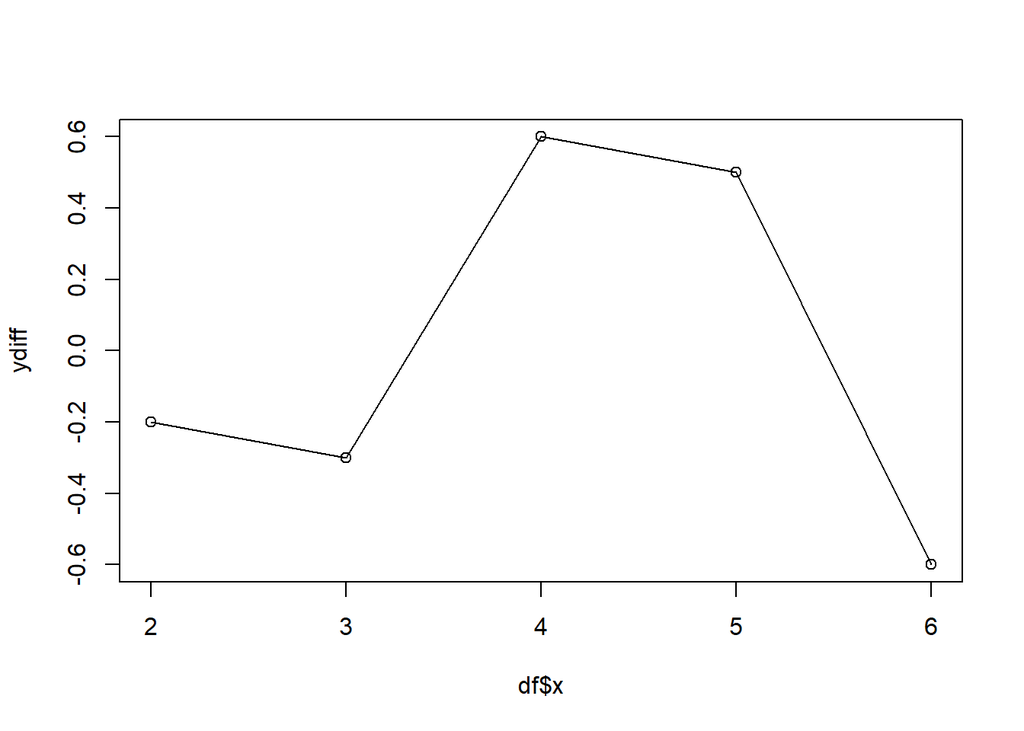

```r
plot(df$x,ydiff,type="o")
```

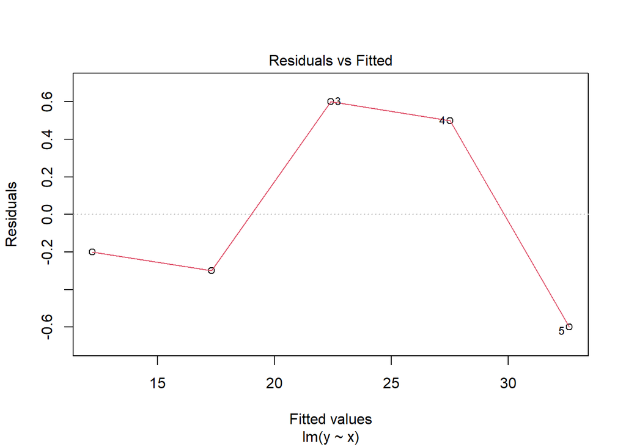

```r
plot(model1,1)
```

```r
#Conclusion The Residuals Seem to be randomly scattered which says model is a good fit for the prediction of target variable y
```

5. Evaluate the Standard errors associated with a and b

```r
rse=sqrt(rss/3)
mx=mean(x)
my=mean(y)
deviations=x-mx
sdeviations=sum(deviations*deviations)
sdeviations
```

```
## [1] 10
```

```r
SE_a=rse*(sqrt(1/sdeviations))
SE_b=rse*(sqrt((1/5)+(mx*mx/sdeviations)))
print(SE_a)
```

```
## [1] 0.1914854
```

```r
print(SE_b)
```

```
## [1] 0.8124038
```

```r
b=model1$coefficients[1]
a=model1$coefficients[2]
conf_b=c(b-2*SE_b,b+2*SE_b)
conf_b
```

```
## (Intercept) (Intercept)
##   0.3751923   3.6248077
```

7.Compute the R-Square Statistic

```r
tssv=y-my
tss=sum(tssv*tssv)
print(tss)
```

```
## [1] 261.2
```

```r
rsquare=1-(rss/tss)
print(rsquare)
```

```
## [1] 0.9957887
```

8.Predict the value of a test instance from the dataset

```r
testf=data.frame(x=c(34,5,7,2,5,4,6,8,3))
predict(model1,testf)
```

```
##     1     2     3     4     5     6     7     8     9
## 175.4  27.5  37.7  12.2  27.5  22.4  32.6  42.8  17.3
```

2<sup>nd</sup> Question:  
I Loading the Dataset and building the linear model

```r
Guns<-read_csv("C:/Users/ayuar/Downloads/Guns.csv")
```

```
## ──────────────────────────────────────────────────────── Delimiter: "," chr
## (2): state, law dbl (12): ...1, year, violent, murder, robbery, prisoners,
## afam, cauc, male,...
```

```r
summary(Guns)
```

```
##       ...1           year         violent           murder
##  Min.   :   1   Min.   :1977   Min.   :  47.0   Min.   : 0.200
##  1st Qu.: 294   1st Qu.:1982   1st Qu.: 283.1   1st Qu.: 3.700
##  Median : 587   Median :1988   Median : 443.0   Median : 6.400
##  Mean   : 587   Mean   :1988   Mean   : 503.1   Mean   : 7.665
##  3rd Qu.: 880   3rd Qu.:1994   3rd Qu.: 650.9   3rd Qu.: 9.800
##  Max.   :1173   Max.   :1999   Max.   :2921.8   Max.   :80.600
##     robbery         prisoners           afam              cauc
##  Min.   :   6.4   Min.   :  19.0   Min.   : 0.2482   Min.   :21.78
##  1st Qu.:  71.1   1st Qu.: 114.0   1st Qu.: 2.2022   1st Qu.:59.94
##  Median : 124.1   Median : 187.0   Median : 4.0262   Median :65.06
##  Mean   : 161.8   Mean   : 226.6   Mean   : 5.3362   Mean   :62.95
##  3rd Qu.: 192.7   3rd Qu.: 291.0   3rd Qu.: 6.8507   3rd Qu.:69.20
##  Max.   :1635.1   Max.   :1913.0   Max.   :26.9796   Max.   :76.53
##       male         population          income         density
##  Min.   :12.21   Min.   : 0.4027   Min.   : 8555   Min.   : 0.000707
##  1st Qu.:14.65   1st Qu.: 1.1877   1st Qu.:11935   1st Qu.: 0.031911
##  Median :15.90   Median : 3.2713   Median :13402   Median : 0.081569
##  Mean   :16.08   Mean   : 4.8163   Mean   :13725   Mean   : 0.352038
##  3rd Qu.:17.53   3rd Qu.: 5.6856   3rd Qu.:15271   3rd Qu.: 0.177718
##  Max.   :22.35   Max.   :33.1451   Max.   :23647   Max.   :11.102120
##     state               law
##  Length:1173        Length:1173
##  Class :character   Class :character
##  Mode  :character   Mode  :character
##
##
##
```

```r
head(Guns,5)
```

```
## # A tibble: 5 × 14
##    ...1  year violent murder robbery prisoners  afam  cauc  male popula…¹ income
##   <dbl> <dbl>   <dbl>  <dbl>   <dbl>     <dbl> <dbl> <dbl> <dbl>    <dbl>  <dbl>
## 1     1  1977    414.   14.2    96.8        83  8.38  55.1  18.2     3.78  9563.
## 2     2  1978    419.   13.3    99.1        94  8.35  55.1  18.0     3.83  9932
## 3     3  1979    413.   13.2   110.        144  8.33  55.1  17.8     3.87  9877.
## 4     4  1980    448.   13.2   132.        141  8.41  54.9  17.7     3.90  9541.
## 5     5  1981    470.   11.9   126.        149  8.48  54.9  17.7     3.92  9548.
## # … with 3 more variables: density <dbl>, state <chr>, law <chr>, and
## #   abbreviated variable name ¹population
```

```r
model2<-lm(cauc~afam,data=Guns)
summary(model2)
```

```
##
## Call:
## lm(formula = cauc ~ afam, data = Guns)
##
## Residuals:
##     Min      1Q  Median      3Q     Max
## -5.1009 -1.0040  0.0102  1.1171  5.4893
##
## Coefficients:
##             Estimate Std. Error t value Pr(>|t|)
## (Intercept) 73.41497    0.07982   919.8   <2e-16 ***
## afam        -1.96198    0.01103  -177.8   <2e-16 ***
## ---
## Signif. codes:  0 '***' 0.001 '**' 0.01 '*' 0.05 '.' 0.1 ' ' 1
##
## Residual standard error: 1.846 on 1171 degrees of freedom
## Multiple R-squared:  0.9643, Adjusted R-squared:  0.9643
## F-statistic: 3.161e+04 on 1 and 1171 DF,  p-value: < 2.2e-16
```

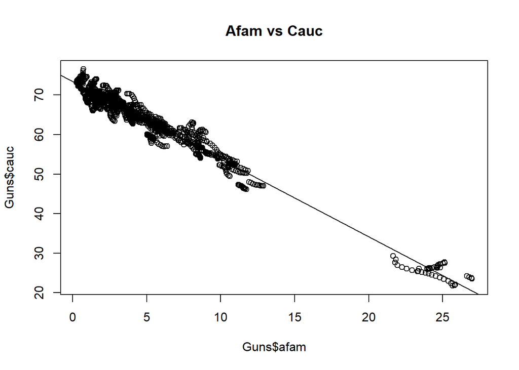

```r
plot(Guns$afam,Guns$cauc,main="Afam vs Cauc")
abline(model2,col="black")
```

Conclusion: Looking at the R-Squared Value We Can see 96% of the Variance is explained by the model and looking at the P-value(<0.05), we can conclude the model is a good fit for predicting the cauc also looking at the median of the residuals which is close to 0

II Determine the RSS

```r
rss2=deviance(model2)
print(rss2)
```

```
## [1] 3988.929
```

III Draw the Residual Plot and Comment on the suitability of the linear model to this training data

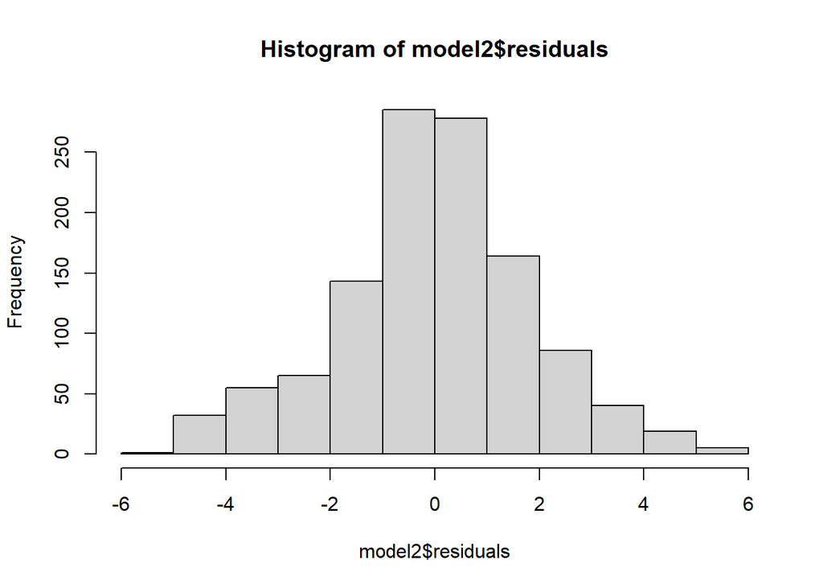

```r
hist(model2$residuals)
```

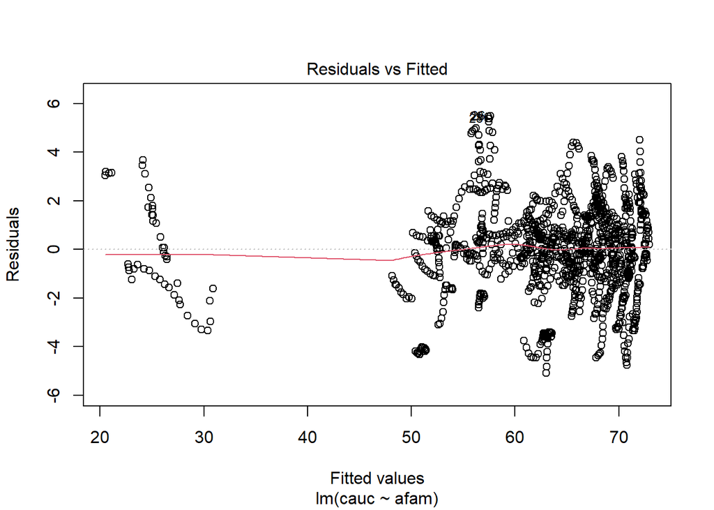

```r
plot(model2,1)
```

IV Evaluate the Standard errors associated with a and b

```r
rse=sqrt(rss2/1171)
mx=mean(Guns$afam)
my=mean(Guns$cauc)
deviations=Guns$afam-mx
sdeviations=sum(deviations*deviations)
sdeviations
```

```
## [1] 27975.57
```

```r
SE_a=rse*(sqrt(1/sdeviations))
SE_b=rse*(sqrt((1/1173)+(mx*mx/sdeviations)))
print(SE_a)
```

```
## [1] 0.01103469
```

```r
print(SE_b)
```

```
## [1] 0.07982042
```

Conclusion: The smaller the value of the standard error of the estimate, the better the fit of the regression model to the data as Standard Error of b and a are very small we can conclude model is a good fit for the data

V Determine the 95% Confidence Interval of the Model

```r
b=model2$coefficients[1]
a=model2$coefficients[2]
conf_b=c(b-2*SE_b,b+2*SE_b)
conf_b
```

```
## (Intercept) (Intercept)
##    73.25533    73.57461
```

VI Compute the R-Square Statistic

```r
x=summary(model2)$r.squared
print(x)
```

```
## [1] 0.9642815
```

Conclusion: As the R-Square value is Close to 1 we can say the 96% of the variance is explained by the model hence it is a good fit for the Data

VII Predict the value of a test instance from the dataset

```r
set.seed(7)
validationIndex <- caret::createDataPartition(Guns$afam, p=0.80, list=FALSE)
#Splitting the DataSet into Training and Testing Dataset
train <- Guns[validationIndex,]
test <- Guns[-validationIndex,]
predict(model2,test)
```

[output not shown]

Time and Date Verification

```r
Sys.info()
```

```
##           sysname           release           version          nodename
##         "Windows"          "10 x64"     "build 22000" "LAPTOP-8VGUQE0S"
##           machine             login              user    effective_user
##          "x86-64"           "ayuar"           "ayuar"           "ayuar"
```

```r
Sys.time()
```

```
## [1] "2022-12-16 21:48:58 IST"
```

```r
Sys.Date()
```

```
## [1] "2022-12-16"
```